# Reproducible Research

## Week 2

### Assignment 1

Loading the data

```r
activity_data <- read.csv("activity.csv")
library(dplyr)
library(lubridate)
library(ggplot2)
library(timeDate)
```

Group activity data by day, ignoring NA’s - Need to load the dplyr package first, filter NAs and then group_by

```r
activity_cleaned <- filter(activity_data,!is.na(activity_data$steps))
## Format date in activity_cleaned
activity_cleaned$date <- ymd(activity_cleaned$date)
activity_grouped <- group_by(activity_cleaned,date)
activity_summary_byday <- summarise(activity_grouped,StepsSum = sum(steps))
```

Plotting in a histogram

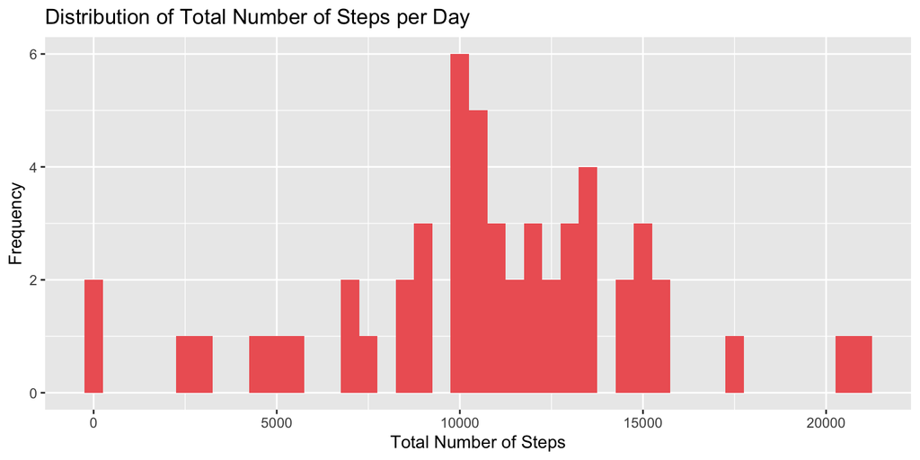

```r
plot <- ggplot(activity_summary_byday,aes(x = StepsSum))
plot + geom_histogram(fill = "indianred2",binwidth = 500) + ggtitle("Distribution of Total Number of Steps per Day") + xlab("Total Number of Steps") + ylab("Frequency")
```

```r
mean <- mean(activity_summary_byday$StepsSum)
median <- median(activity_summary_byday$StepsSum)
```

Average daily activity pattern

```r
activity_interval <- activity_cleaned %>% group_by(interval) %>% summarise(MeanSteps = mean(steps))
```

Plot the results

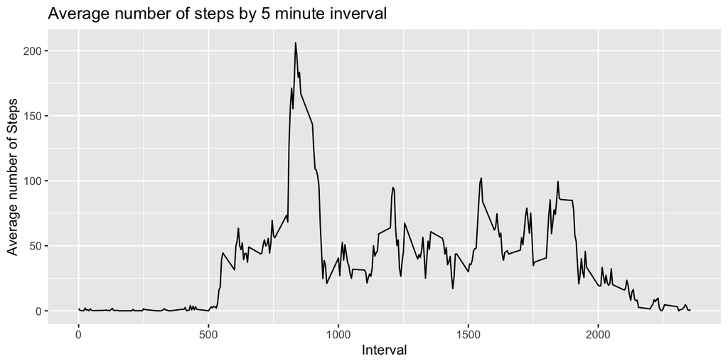

```r
plot2 <- ggplot(activity_interval,aes(x=interval,y=MeanSteps))
plot2 + geom_line() + ggtitle("Average number of steps by 5 minute inverval") + xlab("Interval") + ylab("Average number of Steps")
```

Interval with max steps

```r
max_interval <- activity_interval[which.max(activity_interval$MeanSteps),]
```

The interval with the maximum mean value of steps is 835

Imputing missing values, using average by interval as detailed in previous steps

```r
missing_sum <- sum(is.na(activity_data$steps))
activity_filled <- activity_data
## Fill in data with average values
nas <- is.na(activity_filled$steps)
interval_mean <- tapply(activity_filled$steps, activity_filled$interval, mean, na.rm=TRUE, simplify=TRUE)
activity_filled$steps[nas] <- interval_mean[as.character(activity_filled$interval[nas])]
```

The total number of rows with NAs is 2304

Calculate the total number of steps each day, including these filled in missing values

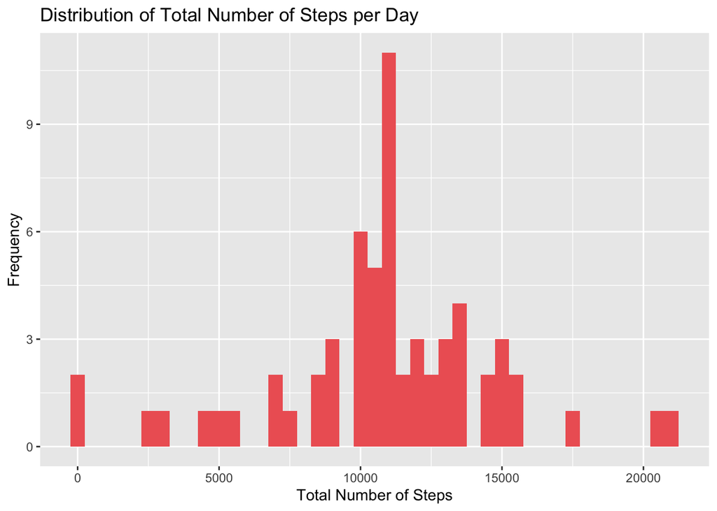

```r
## Format date in activity_cleaned
activity_filled$date <- ymd(activity_filled$date)
activity_filled_grouped <- group_by(activity_filled,date)
activity_filled_byday <- summarise(activity_filled_grouped,StepsSum = sum(steps))

plot3 <- ggplot(activity_filled_byday, aes(x=StepsSum))
plot3 + geom_histogram(fill = "indianred2",binwidth = 500) + ggtitle("Distribution of Total Number of Steps per Day") + xlab("Total Number of Steps") + ylab("Frequency")
```

```r
mean_filled <- mean(activity_filled_byday$StepsSum)
median_filled <- median(activity_filled_byday$StepsSum)
```

Determine if there is differing activity patterns between weekends and weekdays  
First need to split by weekday/weekend, using isWeekday from timeDate package

```r
activity_filled <- mutate(activity_filled, Weekday = as.factor( ifelse(isWeekday(activity_filled$date),"Weekday","Weekend")))
```

Summarise by interval and weekday flag

```r
activity_interval_weektype <- activity_filled %>% group_by(interval,Weekday) %>% summarise(MeanSteps = mean(steps))
```

Chart results

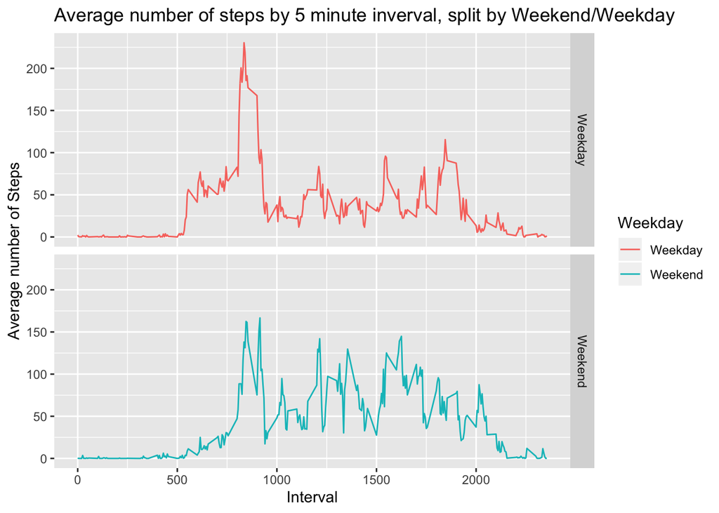

```r
plot4 <- ggplot(activity_interval_weektype, aes(x = interval, y = MeanSteps, col = Weekday))
plot4 + geom_line() + facet_grid(rows = vars(Weekday)) + ggtitle("Average number of steps by 5 minute inverval, split by Weekend/Weekday") + xlab("Interval") + ylab("Average number of Steps")
```